# IIA-3 Econometrics: Supervision 8

Emre Usenmez

Lent Term 2025

Very grateful to Dr Oleg Kitov and Dr Clive Lawson for the very informative stylized answers to previous iterations of the supervision questions.

# FACULTY QUESTIONS

## QUESTION A:

# SUPPLEMENTARY QUESTIONS

## QUESTION 1

### (iii) What would the mean and variance of $z_t$ be if $\rho=1$?

## QUESTION 2

### (i) Obtain the time series plot of the variable `Winner` (Graphics/Time-series graphs/line plotes - (tsline)) and characgterise the corresponding data generating process.

In R:

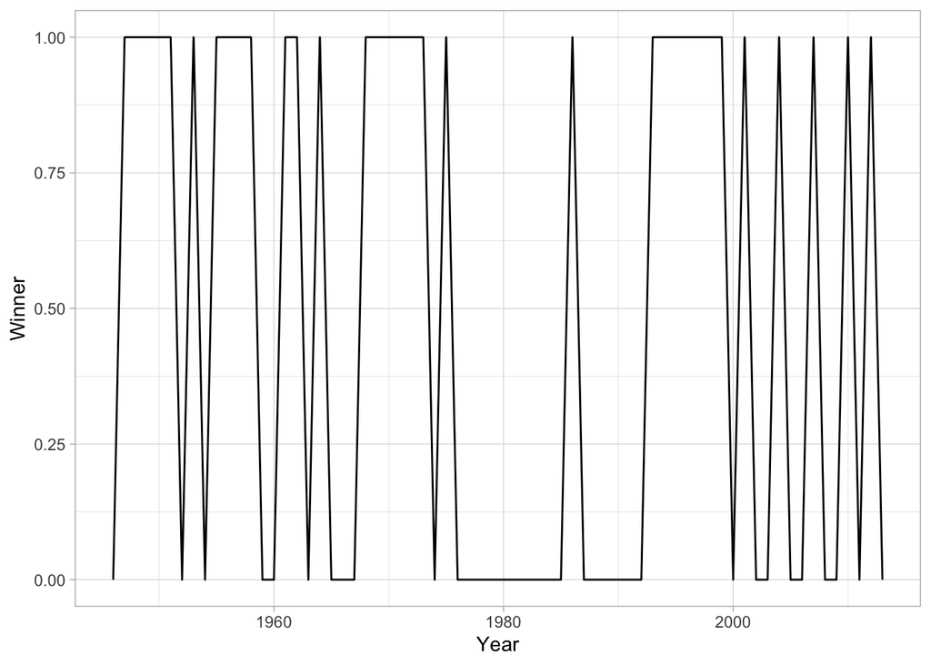

```r
boat_df <- read_dta("../Data/BoatRace.dta")
ggplot(boat_df,
       aes(x=Year, y=Winner)) +
  geom_line() +
  theme_light()
```

There does not seem to be a clear pattern. The plot switches from 0 to 1 and looks pretty random. It would be difficult to predict.

### (ii) Obtain the sample correlogram of `Winner` (Graphics/Time-Series graphs/Correlogram - (ac)). What does the correlogram tell us about serial correlation in `Winner`?

In R:

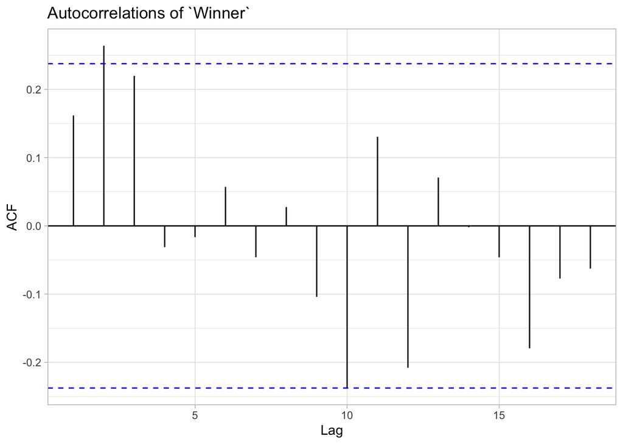

```r
ggAcf(boat_df$Winner) +
  ggtitle("Autocorrelations of `Winner`") +
  theme_light()
```

Let’s unpack what we just plotted. We are beginning to test for stationarity. This graphical test is called (ACF). The ACF at lag $k$ is defined as:
$${ACF}_k = \frac{\gamma_k}{\gamma_0} = \frac{\text{covariance at lag
}k}{\text{variance}}.$$
Since both the numerator and the denominator are measured in the same units of measurement, ${ACF}_k$ is a unitless number. It lies between +1 and -1 as any correlation coefficient.

We don’t usually know the population but only a realization, i.e. sample, of a stochastic process, we can only compute the sample autocorrelation function, $\widehat{{ACF}}_k$:
$$\widehat{{ACF}}_k = \frac{\hat{\gamma}_k}{\hat{\gamma}_0} =
\frac{\displaystyle\frac{\sum(Y_t-\bar{Y})(Y_{t+k}-\bar{Y})}{n}}{\displaystyle\frac{\sum(Y_t-\bar{Y})^2}{n}}$$
The graph above is the sample correlogram that plots $\widehat{{ACF}}_k$ against $k$. The dashed lines gives the 95% confidence intervals that the autocorrelations are not different from 0. Bartlett (1946) has shown that for a time series that follows white noise, the standard error of the autocorrelation is approximately:
$$se(\widehat{{ACF}}_k) \approx \frac{1}{\sqrt{n}}$$
The 95% confidence interval is then computed as:
$${CI}_{95\%} = \pm\frac{1.96}{se(\widehat{{ACF}}_k)} =
\pm\frac{1.96}{\sqrt{n}}$$
In this question $n=68$ so the 95% CI is $\pm 0.2377$. The plot looks similar to a white noise where the autocorrelations seem to hover around 0 at various lags. At the same time there seems to be a positive correlation between $W_t$ and $W_{t-2}$ that is only just statistically significant. The third lag is also close to being significant. Perhaps this may be due to some combination of the boat staying the same for over 2 or 3 years, which is the length of stay for the undergraduates.

We can also use the or which instead of testing the statistical significance of any individual autocorrelation coefficient tests the joint hypothesis that all the $\widehat{{ACF}}_k$ up to certain lags are simultaneously equal to 0:
$$Q = n\sum_{k=1}^m\widehat{{ACF}}_k^2$$
where $n$ is the sample size and $m$ is the lag length. In large samples, it is distributed as $\chi^2$ distribution with $m$ degrees of freedom. If the computed $Q$ is greater than the critical $Q$ value from the $\chi^2$ distribution at the specified significance level, then the null hypothesis is rejected, meaning that at least one or more of the correlation coefficients are nonzero.

A variant of the Box-Pierce Q statistic is the which is defined as:
$$LB = n(n+2)\sum_{k=1}^m\Bigg(\frac{\widehat{{ACF}}_k^2}{n-k}\Bigg) \sim
\chi_m^2.$$
Although in large samples both Q and LB statistics follow the chi-square distribution with $m$ degrees of freedom, the LB statistic has been found to have more statistically powerful small-sample properties than the Q statistic.

```stata
quietly cd ..
use Data/BoatRace.dta
ac Winner
wntestq Winner, lags(4)
wntestq Winner, lags(5)
corrgram Winner
```

```
Portmanteau test for white noise
---------------------------------------
 Portmanteau (Q) statistic =    10.5031
 Prob > chi2(4)            =     0.0328


Portmanteau test for white noise
---------------------------------------
 Portmanteau (Q) statistic =    10.5237
 Prob > chi2(5)            =     0.0617

                                          -1       0       1 -1       0       1
 LAG       AC       PAC      Q     Prob>Q  [Autocorrelation]  [Partial autocor]
-------------------------------------------------------------------------------
1        0.1619   0.1640    1.862  0.1724          |-                 |-
2        0.2640   0.2471   6.8902  0.0319          |--                |-
3        0.2199   0.1611   10.431  0.0152          |-                 |-
4       -0.0312  -0.1649   10.503  0.0328          |                 -|
5       -0.0165  -0.1088   10.524  0.0617          |                  |
6        0.0571   0.0934   10.774  0.0956          |                  |
7       -0.0460   0.0090   10.939  0.1413          |                  |
8        0.0276   0.0340   10.999  0.2017          |                  |
9       -0.1040  -0.1934   11.872  0.2206          |                 -|
10      -0.2374  -0.2832   16.496  0.0863         -|                --|
11       0.1306   0.4187    17.92  0.0835          |-                 |---
12      -0.2079  -0.2294   21.595  0.0423         -|                 -|
13       0.0708   0.1971   22.029  0.0549          |                  |-
14      -0.0019  -0.2162    22.03  0.0780          |                 -|
15      -0.0461   0.0044    22.22  0.1022          |                  |
16      -0.1794  -0.3340   25.167  0.0669         -|                --|
17      -0.0773   0.1831   25.725  0.0796          |                  |-
18      -0.0626  -0.0176   26.097  0.0976          |                  |
19      -0.1370  -0.2397   27.922  0.0849         -|                 -|
20      -0.0635  -0.0381   28.321  0.1020          |                  |
21       0.0101   0.3063   28.331  0.1310          |                  |--
22       0.1140   0.1719   29.676  0.1265          |                  |-
23       0.0110   0.0740   29.689  0.1585          |                  |
24       0.2023   0.0717   34.116  0.0826          |-                 |
25       0.0992  -0.1290   35.206  0.0845          |                 -|
26       0.1140  -0.2462   36.678  0.0799          |                 -|
27      -0.1068  -0.4262   38.003  0.0778          |               ---|
28      -0.0047   0.0150   38.006  0.0983          |                  |
29      -0.0186  -0.1144   38.048  0.1213          |                  |
30      -0.1216  -0.2116     39.9  0.1068          |                 -|
31      -0.0766  -0.6229   40.655  0.1149          |              ----|
32      -0.0905  -1.2845   41.736  0.1164          |          --------|
```

This looks pretty indecisive. We cannot reject the null that all the autocorrelation coefficients are jointly equal to 0 at 5% significance when we use 5 lags, but we can reject when we use 4 lags.

There is not a direct equivalent command in R but we can replicate the table above in R by building our own function:

```r
r_corrgram_extended <- function(time_series, lag.max = 20) {
  n <- length(time_series)

  # Calculate ACF and PACF
  acf_result <- acf(time_series, lag.max = lag.max, plot = FALSE)
  pacf_result <- pacf(time_series, lag.max = lag.max, plot = FALSE)

  # Calculate standard errors
  se_acf <- rep(1/sqrt(n), lag.max)

  # Initialize vectors for Q statistics and p-values
  q_stats <- numeric(lag.max)
  p_values <- numeric(lag.max)

  # Calculate Q statistics for each lag
  for (i in 1:lag.max) {
    box_test <- Box.test(time_series, lag = i, type = "Ljung-Box")
    q_stats[i] <- box_test$statistic
    p_values[i] <- box_test$p.value
  }

  # Create results data frame
  results <- data.frame(
    Lag = 1:lag.max,
    AC = round(acf_result$acf[-1],4),  # Remove lag 0
    se_AC = round(se_acf,4),
    PAC = round(pacf_result$acf,4),
    Q = round(q_stats,4),
    Prob_Q = round(p_values,4)
  )

  return(results)
}


r_corrgram_extended(boat_df$Winner)
```

[output not shown]

Another test we can use to check for stationarity is the . Consider the stochastic process
$$Y_t = \rho Y_{t-1}+u_t \ \ \ , \ \ \ -1\leq\rho\leq1$$
where u_t is a white noise error term. If $\rho=1$, i.e when we have a unit root, then the stochastic process above is a random walk model without drift, which is a nonstationary stochastic process. The idea of the test is then to regress $Y_t$ on its one lagged period and check if the estimated coefficient is equal to 1 or not. If it is, then $Y_t$ is nonstationary.

However, we cannot estimate this equation by OLS and use the usual $t$ test to test if the coefficient is equal to 1 because the test itself is severely biased in the case of a unit root. To tackle this, we subtract $Y_{t-1}$ from both sides to obtain:
$$\begin{align*}
Y_t - Y_{t-1} &= \rho Y_{t-1} - Y_{t-1} + u_t \\
\Delta Y_t &= (\rho - 1)Y_{t-1} + u_t \\
\Delta Y_t &= \delta Y_{t-1} + u_t.
\end{align*}$$
It is this equation that is then estimated. The null hypothesis is that $\delta=0$ with the alternative being $\delta<0$ since $|\rho|<1$ for stationarity to hold.

The only thing left to consider now for the unit root test is which test to use to see if the coefficient of $Y_{t-1}$ is 0 or negative in this first differenced equation. We cannot use $t$ test because the $t$ value of $\hat{\delta}$ does not follow the $t$ distribution even in large samples; i.e. it does not have an asymptotic normal distribution.

In this question, we can run the test as follows:

```stata
quietly cd ..
use Data/BoatRace.dta
dfuller Winner
dfuller Winner, drift
dfuller Winner, trend
```

```
Dickey–Fuller test for unit root           Number of obs  = 67
Variable: Winner                           Number of lags =  0

H0: Random walk without drift, d = 0

                                       Dickey–Fuller
                   Test      -------- critical value ---------
              statistic           1%           5%          10%
--------------------------------------------------------------
 Z(t)            -6.833       -3.556       -2.916       -2.593
--------------------------------------------------------------
MacKinnon approximate p-value for Z(t) = 0.0000.


Dickey–Fuller test for unit root           Number of obs  = 67
Variable: Winner                           Number of lags =  0

H0: Random walk with drift, d = 0

                                      t-distribution
                   Test      -------- critical value ---------
              statistic           1%           5%          10%
--------------------------------------------------------------
 Z(t)            -6.833       -2.385       -1.669       -1.295
--------------------------------------------------------------
p-value for Z(t) = 0.0000


Dickey–Fuller test for unit root           Number of obs  = 67
Variable: Winner                           Number of lags =  0

H0: Random walk with or without drift

                                       Dickey–Fuller
                   Test      -------- critical value ---------
              statistic           1%           5%          10%
--------------------------------------------------------------
 Z(t)            -7.074       -4.113       -3.483       -3.170
--------------------------------------------------------------
MacKinnon approximate p-value for Z(t) = 0.0000.
```

This tells us that in any of the specifications the stochastic process is stationary.

In conducting the DF test it was assumed that the error term $u_t$ were uncorrelated. In case they are correlated, Dickey and Fuller have developed the . This test is conducted by augmenting the preceding three equations by adding the lagged values of the dependent variable $\Delta Y_t$. So, for example, suppose we are using random walk with a drift around a deterministic trend equation. The ADF test then consists of estimating the following regression:
$$\Delta Y_t = \beta_0 + \beta_1\ t + \delta\ Y_{t-1} +
\sum_{i=1}^m\alpha_i\Delta Y_{t-i} + \varepsilon_t$$
where $\varepsilon_t$ is a pure white noise error term and where $\Delta Y_{t-1} = (Y_{t-1}-Y_{t-2}), \Delta Y_{t-2} = (Y_{t-2}-Y_{t-3})$ etc. The number of lagged difference terms to include is often determined empirically, the idea being to include enough terms so that the error term is serially uncorrelated, which would allow us to obtain unbiased estimate of $\delta$.

Lets try with 1 lag on the random walk without a drift or trend equation:

```stata
quietly cd ..
use Data/BoatRace.dta
dfuller Winner, lags(1) regress
```

```
Augmented Dickey–Fuller test for unit root

Variable: Winner                           Number of obs  = 66
                                           Number of lags =  1

H0: Random walk without drift, d = 0

                                       Dickey–Fuller
                   Test      -------- critical value ---------
              statistic           1%           5%          10%
--------------------------------------------------------------
 Z(t)            -3.945       -3.558       -2.917       -2.594
--------------------------------------------------------------
MacKinnon approximate p-value for Z(t) = 0.0017.

Regression table
------------------------------------------------------------------------------
    D.Winner | Coefficient  Std. err.      t    P>|t|     [95% conf. interval]
-------------+----------------------------------------------------------------
      Winner |
         L1. |  -.6159696   .1561211    -3.95   0.000    -.9279526   -.3039865
         LD. |  -.2471483   .1220797    -2.02   0.047    -.4911051   -.0031915
       _cons |   .2965779   .0975263     3.04   0.003     .1016871    .4914688
------------------------------------------------------------------------------
```

In R we can obtain the same results via the following:

```r
# Basic Dickey-Fuller test (equivalent to Stata's dfuller y)
df_test <- ur.df(boat_df$Winner, type = "none", lags = 0)
summary(df_test)

# With trend (equivalent to Stata's dfuller y, trend)
df_trend_test <- ur.df(boat_df$Winner, type = "trend", lags = 0)
summary(df_trend_test)

# With drift/constant (equivalent to Stata's dfuller y, drift)
df_drift_test <- ur.df(boat_df$Winner, type = "drift", lags = 0)
summary(df_drift_test)

# Augmented Dickey-Fuller with lags (equivalent to Stata's dfuller y, lags(1))
adf_test <- ur.df(boat_df$Winner, type = "none", lags = 1)
summary(adf_test)

# With automatic lag selection (similar to Stata's dfuller y, lags(AIC))
max_lags <- floor(12 * (length(boat_df$Winner)/100)^(1/4))  # Rule of thumb
adf_auto <- ur.df(boat_df$Winner, type = "none", selectlags = "AIC", lags = max_lags)
summary(adf_auto)
```

[output not shown]

### (iii) Make a time series plot of the variable `WinTime` and briefly describe its behavior.

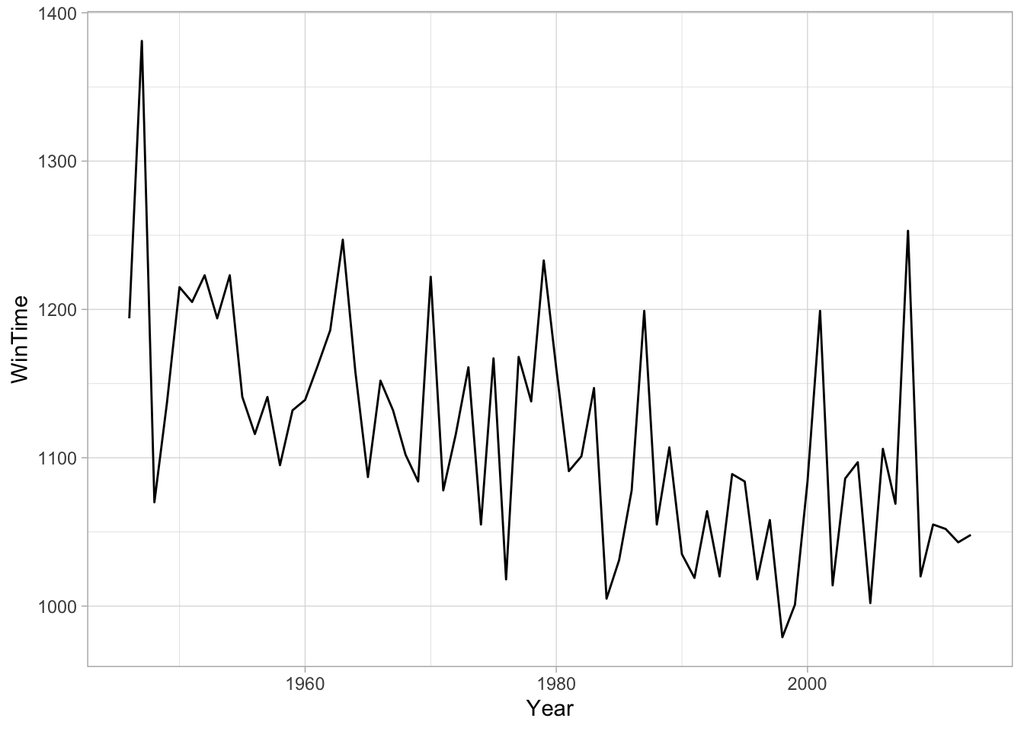

```r
ggplot(boat_df,
       aes(x=Year, y=WinTime)) +
  geom_line() +
  theme_light()
```

It looks like there is a trend of decline in time, possibly bottoming out later in the series. We can check for stationarity looking at the autocorrelations:

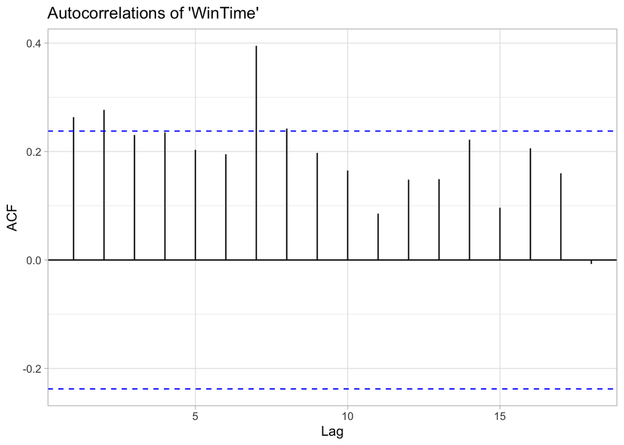

```r
ggAcf(boat_df$WinTime) +
  ggtitle("Autocorrelations of 'WinTime'") +
  theme_light()
```

We can run a DF test using random walk with trend since there seems to be a downward trend.

```stata
quietly cd ..
use Data/BoatRace.dta
dfuller WinTime, trend regress
```

```
Dickey–Fuller test for unit root           Number of obs  = 67
Variable: WinTime                          Number of lags =  0

H0: Random walk with or without drift

                                       Dickey–Fuller
                   Test      -------- critical value ---------
              statistic           1%           5%          10%
--------------------------------------------------------------
 Z(t)            -8.601       -4.113       -3.483       -3.170
--------------------------------------------------------------
MacKinnon approximate p-value for Z(t) = 0.0000.

Regression table
------------------------------------------------------------------------------
   D.WinTime | Coefficient  Std. err.      t    P>|t|     [95% conf. interval]
-------------+----------------------------------------------------------------
     WinTime |
         L1. |  -1.072409   .1246814    -8.60   0.000    -1.321489   -.8233293
      _trend |  -2.372236   .4925508    -4.82   0.000     -3.35622   -1.388253
       _cons |   1274.021   149.3008     8.53   0.000     975.7581    1572.283
------------------------------------------------------------------------------
```

From the $Z(t)$ results we can reject the null hypothesis at all common significant levels and conclude that $\delta < 0$ and thus the stochastic process is stationary. $\delta = -1.07$ implies that $\rho = 1-1.07 = -0.07$.

### (iv) Note that `DWinTime` in your data set is obtained by taking the first differences of `WinTime`. Suppose that the data generating process for `WinTime` is given by the following:

$${WinTime}_t = \gamma + \delta\ Year_t + v_t$$

```stata
quietly cd ..
use Data/BoatRace.dta
reg WinTime t
```

```
      Source |       SS           df       MS      Number of obs   =        68
-------------+----------------------------------   F(1, 66)        =     31.94
       Model |  128954.652         1  128954.652   Prob > F        =    0.0000
    Residual |  266506.569        66  4037.97832   R-squared       =    0.3261
-------------+----------------------------------   Adj R-squared   =    0.3159
       Total |  395461.221        67  5902.40628   Root MSE        =    63.545

------------------------------------------------------------------------------
     WinTime | Coefficient  Std. err.      t    P>|t|     [95% conf. interval]
-------------+----------------------------------------------------------------
           t |   -2.21867   .3926053    -5.65   0.000    -3.002532   -1.434808
       _cons |   1190.382   15.58351    76.39   0.000     1159.269    1221.496
------------------------------------------------------------------------------
```

### (v) Generate the sample correlogram of `DWinTime`. Are your results expected?

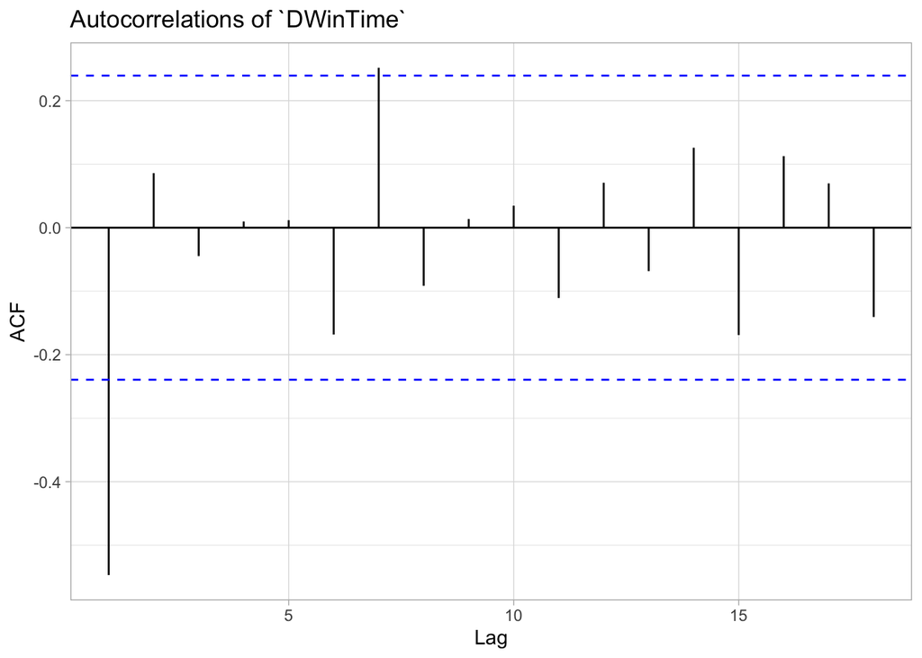

```r
ggAcf(boat_df$DWinTime) +
  ggtitle("Autocorrelations of `DWinTime`") +
  theme_light()
```

This confirms that $\rho_1 \approx -0.5$.

## QUESTION 3

### (i) Using data from the file Timeseries1.dta, estimate the following equations.

$$\begin{align}
C_t &= \rho + \psi Y_t + \varepsilon_t \label{eq:3i1} \\
C_t &= \alpha +\beta Y_t + \gamma Y_{t-1} + \lambda C_{t-1} +
\varepsilon_t \label{eq:3i2}
\end{align}$$

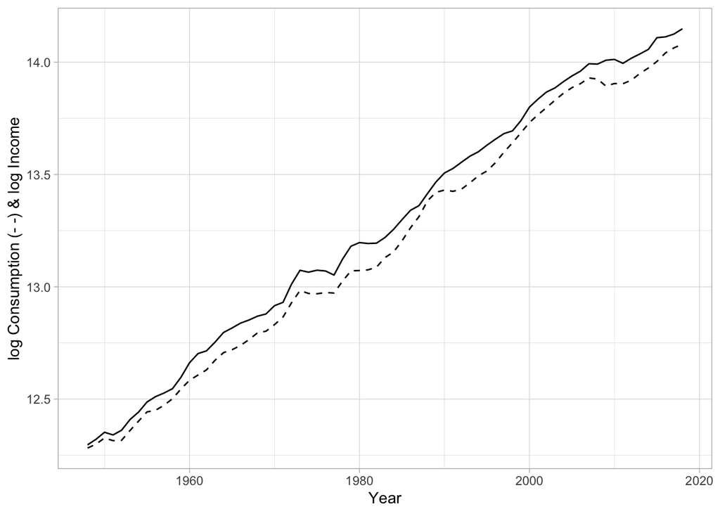

```r
ts_df <- read_dta("../Data/Timeseries1.dta")
ggplot(ts_df,
       aes(x = Year)) +
  geom_line(aes(y = C), linetype = "dashed") +
  geom_line(aes(y = Y)) +
  theme_light() +
  labs(y = "log Consumption (- -) & log Income")
```

They both show a clear upwards trend and a very close relationship with each other. We can estimate that relationship using the first, static model:

```stata
quietly cd ..
use Data/Timeseries1.dta
regress C Y
```

```
      Source |       SS           df       MS      Number of obs   =        71
-------------+----------------------------------   F(1, 69)        =  34857.35
       Model |   22.133814         1   22.133814   Prob > F        =    0.0000
    Residual |  .043813803        69  .000634983   R-squared       =    0.9980
-------------+----------------------------------   Adj R-squared   =    0.9980
       Total |  22.1776278        70  .316823255   Root MSE        =     .0252

------------------------------------------------------------------------------
           C | Coefficient  Std. err.      t    P>|t|     [95% conf. interval]
-------------+----------------------------------------------------------------
           Y |    .985157   .0052766   186.70   0.000     .9746304    .9956836
       _cons |   .1201545   .0701098     1.71   0.091    -.0197107    .2600197
------------------------------------------------------------------------------
```

The equation does not suggest a tradeoff between $Y$ and $C$ since $\hat{\psi}>0$, which we would not have expected anyway.

Now notice that $R^2$ is extremely high at 99.8% and so is the $t$-statistic for the coefficient of $Y$. This may be because they are strongly correlated or due to potential presence of . The nonsensical correlations were first discovered by Yule (1926) who showed that spurious correlations could persist in nonstationary time series even if the sample is very large. In a simulation study, Granger and Newbold (1974) examined spurious relationships between two independent but non-stationary variables $X$ and $Y$ - both were generated by the random walk processes - and estimated the relationship $\hat{Y}_t = \hat{alpha} + \hat{\beta}X_t$. They showed that a potential indicator of a spurious correlation is a low Durbin-Watson statistic combined with an acceptable $R^2$. That is, a good rule of thumb to suspect that the estimated regression is spurious is to check if $R^2>d$.

Recall from Supervision 4 that the $d$ statistic is the ratio of the sum of squared differences between successive residuals to the RSS:
$$DW = d = \frac{\displaystyle\sum_{i=2}^n(\hat{u}_t -
\hat{u}_{t-1})^2}{\sum_{i=1}^n\hat{u_t}^2}$$
: the number of observations in the numerator of the $d$ statistic is one less than the numerator, i.e. $n-1$, because one observation is lost in taking successive differences.

Let’s obtain the $d$ statistic for this regression. For this, in R we use `durbinWatsonTest()` function from the `car` package, or `dwtest` from the `lmtest` package:

```r
SQ3i_lm1 <- lm(C ~ Y, data = ts_df)
car::durbinWatsonTest(SQ3i_lm1)
```

```
 lag Autocorrelation D-W Statistic p-value
   1        0.795736      0.345889       0
 Alternative hypothesis: rho != 0
```

```r
# or
dwtest(SQ3i_lm1)
```

```
    Durbin-Watson test

data:  SQ3i_lm1
DW = 0.3459, p-value <0.0000000000000002
alternative hypothesis: true autocorrelation is greater than 0
```

The same calculation in STATA can be done via the `estat dwatson` command

```stata
quietly cd ..
use Data/Timeseries1.dta
quietly regress C Y
quietly tsset Year
estat dwatson
```

```
Durbin–Watson d-statistic(  2,    71) =  .3458889
```

Which gives us a $d$ statistic of 0.3459 which is much lower than the $R^2$. So what this means is not that there may not be a relationship between $C$ and $Y$ but that the $R^2$ and $t$ statistic from this regression are misleading and that the $t$ statistics are not distributed as Student’s $t$ distribution, meaning it can’t be used for testing hypotheses about the parameters. This can arise because the model we used assumes that the stochastic process is , denoted as $I(0)$. There may be autocorrelations and higher integrated orders may be more appropriate. We can check the correlogram to identify if there are autocorrelations:

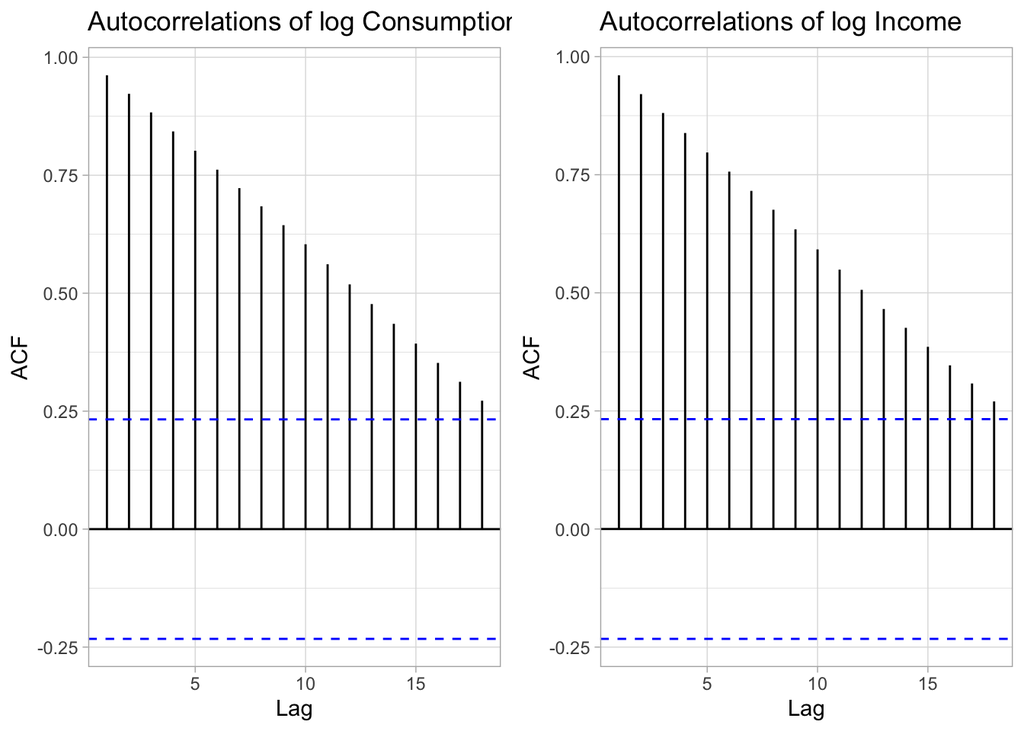

```r
plot1 <- ggAcf(ts_df$C) +
  ggtitle("Autocorrelations of log Consumption") +
  theme_light()
plot2 <- ggAcf(ts_df$Y) +
  ggtitle("Autocorrelations of log Income") +
  theme_light()
grid.arrange(plot1, plot2, ncol=2)
```

which shows that we have strong autocorrelations in both that go back a number of lags.

Lets now look at the second equation.

```stata
quietly cd ..
use Data/Timeseries1.dta
tsset Year
regress C Y L.Y L.C
```

```
Time variable: Year, 1948 to 2018
        Delta: 1 unit

      Source |       SS           df       MS      Number of obs   =        70
-------------+----------------------------------   F(3, 66)        =  39478.85
       Model |    21.31537         3  7.10512335   Prob > F        =    0.0000
    Residual |  .011878213        66  .000179973   R-squared       =    0.9994
-------------+----------------------------------   Adj R-squared   =    0.9994
       Total |  21.3272483        69  .309090554   Root MSE        =    .01342

------------------------------------------------------------------------------
           C | Coefficient  Std. err.      t    P>|t|     [95% conf. interval]
-------------+----------------------------------------------------------------
           Y |
         --. |   .7491507   .0838085     8.94   0.000     .5818217    .9164798
         L1. |  -.6091466   .0903504    -6.74   0.000    -.7895371   -.4287561
           C |
         L1. |    .859517   .0672937    12.77   0.000     .7251608    .9938732
       _cons |   .0013938   .0392322     0.04   0.972    -.0769358    .0797235
------------------------------------------------------------------------------
```

The problem with this estimation is similar to the first equation in that it involves the levels of variables that may be non-stationary. We would need to be hesitant in applying classical techniques as we may encounter spurious regression problems.

### (ii) Estimate the following and interpret your results (and explain the significance of your results for the interpretation of equations ($\ref{eq:3i1}$) and ($\ref{eq:3i2}$) in part (i) on page ):

$$\begin{align}
\Delta Y_t &= \alpha_0 + \alpha_1Y_{t-1} + \varepsilon_t
\label{eq:3ii1} \\
\Delta C_t &= \beta_0 + \beta_1C_{t-1} + \varepsilon_t
\label{eq:3ii2} \\
\Delta C_t &= \gamma_0 + \gamma_1C_{t-1} + \gamma_2\Delta C_{t-1} +
\varepsilon_t \label{eq:3ii3}
\end{align}$$

```r
#Generate lagged variables and differences
ts_df <- ts_df %>%
  mutate(
    Y_lag = lag(Y, 1),
    C_lag = lag(C, 1),
    DY = Y - Y_lag,
    DC = C- C_lag,
    DC_lag = lag(DC, 1)
         )
# Run the three regressions
SQ3ii_lm1 <- lm(DY ~ Y_lag, data = ts_df)
SQ3ii_lm2 <- lm(DC ~ C_lag, data = ts_df)
SQ3ii_lm3 <- lm(DC ~ C_lag + DC_lag, data = ts_df)

# Store models in a list with descriptive names
models <- list(
  "Eq (3)" = SQ3ii_lm1,
  "Eq (4)" = SQ3ii_lm2,
  "Eq (5)" = SQ3ii_lm3
)

# Create a coefficient map for nice variable names
coef_map <- c(
  "Y_lag" = "Y_lag",
  "C_lag" = "C_lag",
  "DC_lag" = "ΔC_lag",
  "(Intercept)" = "Constant"
)

# Generate the table with modelsummary
modelsummary(models,
             coef_map = coef_map,
             stars = TRUE,
             title = "SQ3(ii) Regression Results",
             gof_map = c("nobs", "r.squared", "adj.r.squared", "F"),
             fmt = 5,  # 4 decimal places
             output = "default")  # "default" for console output
```

|  | Eq (3) | Eq (4) | Eq (5) |
| --- | --- | --- | --- |
| Y_lag | -0.00509 |  |  |
|  | (0.00432) |  |  |
| C_lag |  | -0.00205 | -0.00230 |
|  |  | (0.00425) | (0.00392) |
| ΔC_lag |  |  | 0.45054*** |
|  |  |  | (0.10963) |
| Constant | 0.09394 | 0.05269 | 0.04452 |
|  | (0.05733) | (0.05613) | (0.05191) |
| Num.Obs. | 70 | 70 | 69 |
| R2 | 0.020 | 0.003 | 0.208 |
| R2 Adj. | 0.006 | -0.011 | 0.184 |
| F | 1.388 | 0.232 | 8.648 |

+ p < 0.1, * p < 0.05, ** p < 0.01, *** p < 0.001

Recall from Supervision 4, we can use Breusch-Godfrey (Lagrange Multiplier) Test to check for serial correlation

```stata
quietly cd ..
use Data/Timeseries1.dta
quietly tsset Year
quietly generate DY = Y - Y[_n-1]
quietly generate DC = C - L.C

quietly regress DY L.Y
bgodfrey

quietly regress DC L.C
bgodfrey

quietly regress DC L.C L.DC
bgodfrey
```

```
Breusch–Godfrey LM test for autocorrelation
---------------------------------------------------------------------------
    lags(p)  |          chi2               df                 Prob > chi2
-------------+-------------------------------------------------------------
       1     |          3.741               1                   0.0531
---------------------------------------------------------------------------
                        H0: no serial correlation



Breusch–Godfrey LM test for autocorrelation
---------------------------------------------------------------------------
    lags(p)  |          chi2               df                 Prob > chi2
-------------+-------------------------------------------------------------
       1     |         14.172               1                   0.0002
---------------------------------------------------------------------------
                        H0: no serial correlation



Breusch–Godfrey LM test for autocorrelation
---------------------------------------------------------------------------
    lags(p)  |          chi2               df                 Prob > chi2
-------------+-------------------------------------------------------------
       1     |          3.215               1                   0.0730
---------------------------------------------------------------------------
                        H0: no serial correlation
```

It appears that only equation ($\ref{SQii2}$) is serially correlated. We can visually check for the autocorrelation using correlogram:

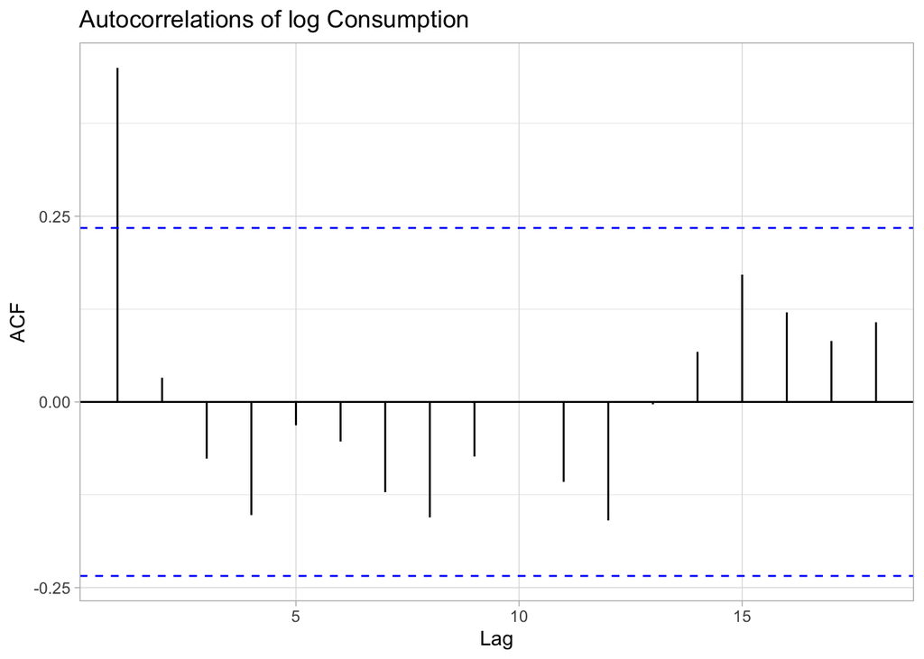

```r
ggAcf(ts_df$DC) +
  ggtitle("Autocorrelations of log Consumption") +
  theme_light()
```

There seems to be a statistically significant correlation with its first lag. This is why equation ($\ref{eq:SQii3}$) is an improvement on ($\ref{eq:SQii2}$). It takes into account the first lag of #C_t$ as well.

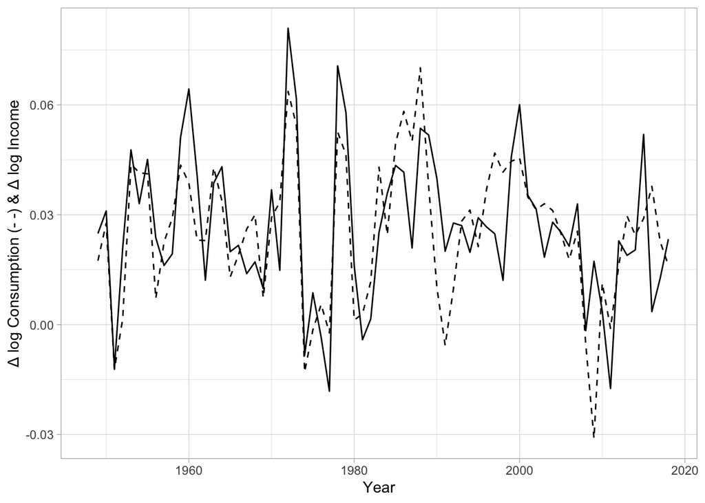

```r
ggplot(ts_df,
       aes(x = Year)) +
  geom_line(aes(y = DC), linetype = "dashed", na.rm=TRUE) +
  geom_line(aes(y = DY), na.rm=TRUE) +
  theme_light() +
  labs(y = "\u0394 log Consumption (- -) & \u0394 log Income")
```

### (iii) Now estimate the following equation:

$$\begin{equation}
\Delta C_t = \alpha + \beta\ \Delta Y_t + (1-\lambda)(Y_{t-1}-C_{t-1}) +
\varepsilon_t \label{eq:SQiii}
\end{equation}$$